# Whale Safe Impact

Author

Emily Nazario

Published

April 13, 2026

# Voluntary Vessel Speed Reduction (VSR) Zone & Whale Safe background

## VSR data notes

San Francisco data does not include the Monterey Bay National Marine Sanctuary, which was added to the VSR program in 2023. The Whale Safe system that was launched in San Francisco was designed to give whale presence in the San Francisco portion of the VSR zones so we are reporting on them separately here for now. The Monterey Bay stats come from a different data pipeline and the offseason stats are not tracked as regularly.

### **Whale Safe System Launch Dates**

Southern California: September 17, 2020

San Francisco: September 21, 2022

### **Vessel Speed Reduction Zones**

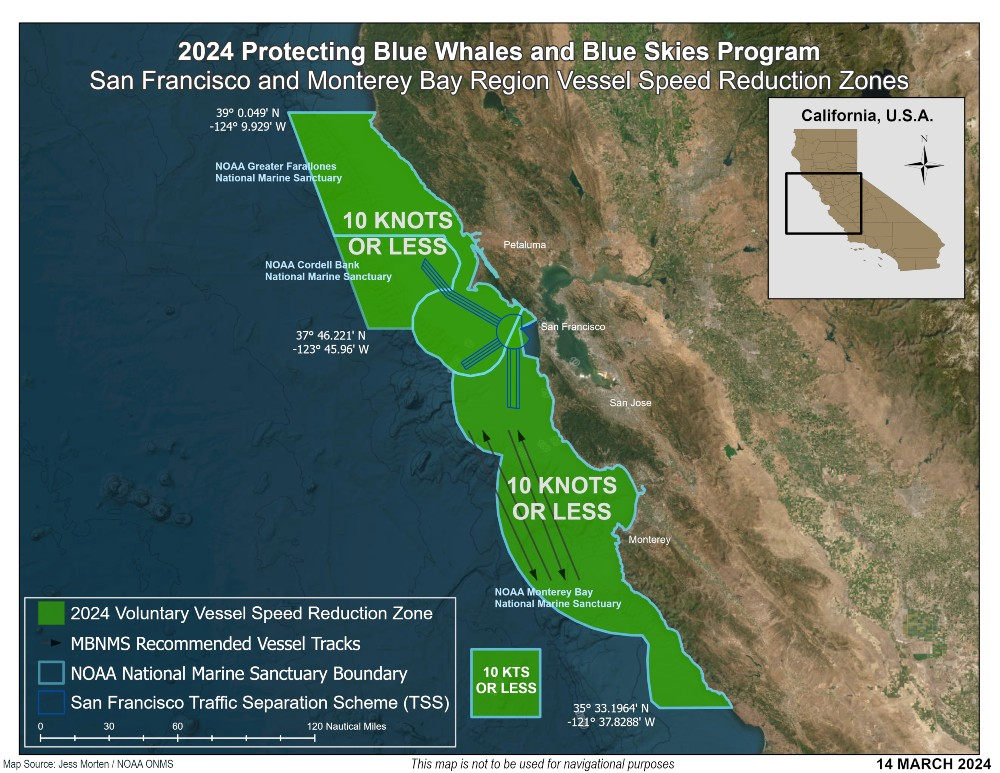

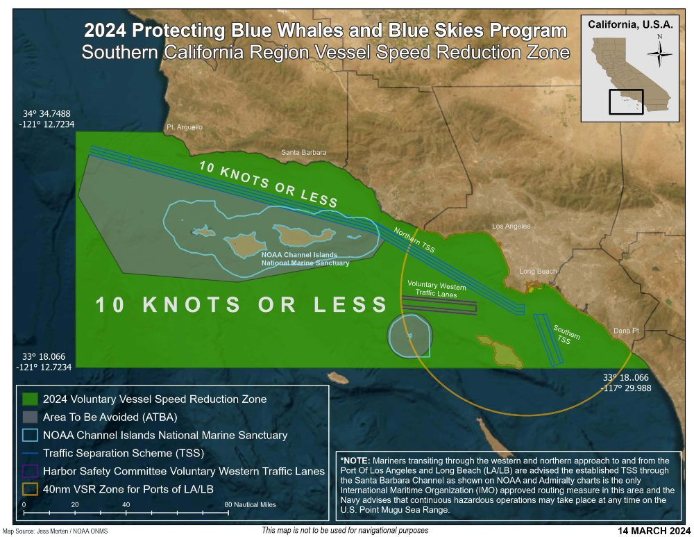

### **Vessel Speed Reduction Season Dates:**

Southern California:

- June 4 - December 31, 2018:
- May 15 - December 15, 2019
- May 15 - December 15, 2020
- May 15 - December 15, 2021
- May 1 - December 15, 2022
- May 1 - December 15, 2023
- May 1 , 2024 - January 15, 2025

San Francisco

- May 1 - November 15, 2019
- May 1 - November 15, 2020
- May 1 - November 15, 2021
- May 1 - December 15, 2022
- May 1 - December 15, 2023
- May 1 , 2024 - January 15, 2025

## WPR data notes

Blue whale model data might have been retroactively filled in after periods where the server was down. We don’t have this tracked in our data so there may be days where the Whale Presence Rating didn’t take the blue whale model value into account.

Each species has a threshold for each data stream see [Methodology](https://whalesafe.com/methodology/) for what is considered low-high (0-1). The Whale Presence Rating considers the highest rating of any of the data streams over 5 days. Two species need to have a *high* rating in order for the overall Whale Presence Rating to be ‘Very High’.

# Blue whale data stream time series

Across metrics, data points represent the year-month average for blue whales. Light grey shaded regions represent seasons when the VSR is active, while the striped regions represent when data was unavailable from the respective source.

For the acoustics panels, year-month averages were done by assigning a “Low Rating” a 1, a “Medium Rating” a 2, a “High Rating” a 3, and “offline” an NA. Then, averages were taken of these scores, and the means were plotted as they fit across the ranges of these three bins.

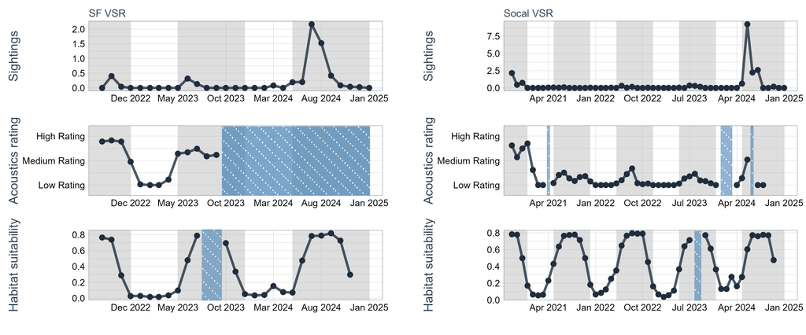

Proportion of days per region data was offline

| Region (n = all days) | Data system | Percent days offline |
| --- | --- | --- |
| San Francisco (n = 846) | Acoustics | 56.03% |
| Southern California (n = 1579) | Acoustics | 24.64% |
| San Francisco (n = 846) | Whale Watch | 20.09% |
| Southern California (n = 1579) | Whale Watch | 11.40% |

# Revised analysis: GLMM

## Sightings ~ SDM

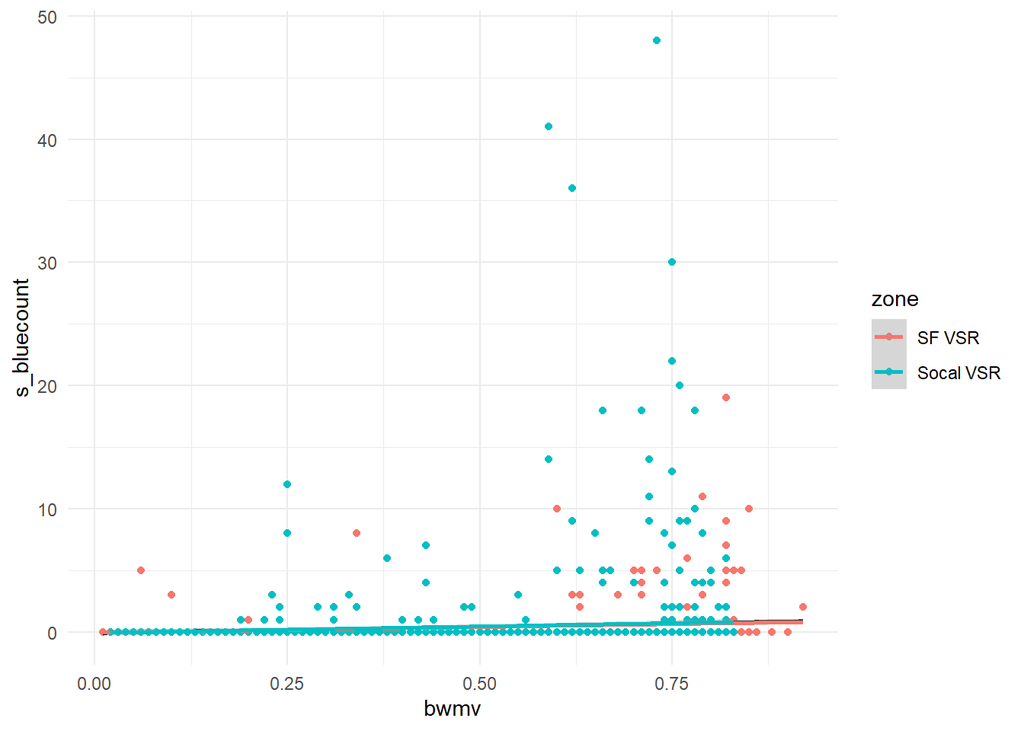

```r
ggplot(wpr, aes(bwmv, s_bluecount)) +
geom_point(aes(color = zone)) +
geom_smooth(data = wpr, aes(bwmv, s_bluecount), color = "black", method = "lm") +
geom_smooth(method = "lm", aes(color = zone)) +
theme_minimal()
```

```r
wpr <- wpr %>% mutate(j_day = format(date_pt, "%j"),
                      blu_acou_deci = blue_acoustic_percent/100,
                      zone = as.factor(zone),
                      month_sin = sin((2*pi*mo)/12),
                      month_cos = cos((2*pi*mo)/12))
wpr$year_c <- wpr$year - mean(wpr$year) #center to make intercept value more interpretable
wpr$zone <- relevel(wpr$zone, ref = "Socal VSR")
n_sight_mod <- wpr %>% filter(!is.na(bwmv)) %>% group_by(zone) #no NAs in sighting data
count(n_sight_mod)
```

```
# A tibble: 2 × 2
# Groups:   zone [2]
  zone          n
  <fct>     <int>
1 Socal VSR  1402
2 SF VSR      678
```

```r
#sightings ~ sdm
sight_sdm <- glmmTMB(s_bluecount ~ bwmv*zone + month_sin + month_cos + (1|year_c),
                    ziformula = ~zone,
                    family = poisson,
                    data = wpr)

summary(sight_sdm)
```

```
 Family: poisson  ( log )
Formula:
s_bluecount ~ bwmv * zone + month_sin + month_cos + (1 | year_c)
Zero inflation:               ~zone
Data: wpr

      AIC       BIC    logLik -2*log(L)  df.resid
   1735.5    1786.3    -858.8    1717.5      2071

Random effects:

Conditional model:
 Groups Name        Variance Std.Dev.
 year_c (Intercept) 1.574    1.255
Number of obs: 2080, groups:  year_c, 5

Conditional model:
                Estimate Std. Error z value Pr(>|z|)
(Intercept)      -0.8479     0.6231  -1.361  0.17358
bwmv              0.9675     0.4515   2.143  0.03211 *
zoneSF VSR        0.3361     0.4626   0.727  0.46752
month_sin        -0.6233     0.1918  -3.250  0.00115 **
month_cos        -1.2666     0.1914  -6.619 3.61e-11 ***
bwmv:zoneSF VSR  -1.0758     0.6128  -1.756  0.07917 .
---
Signif. codes:  0 '***' 0.001 '**' 0.01 '*' 0.05 '.' 0.1 ' ' 1

Zero-inflation model:
            Estimate Std. Error z value Pr(>|z|)
(Intercept)   1.9297     0.1486  12.984   <2e-16 ***
zoneSF VSR    0.2567     0.2525   1.017    0.309
---
Signif. codes:  0 '***' 0.001 '**' 0.01 '*' 0.05 '.' 0.1 ' ' 1
```

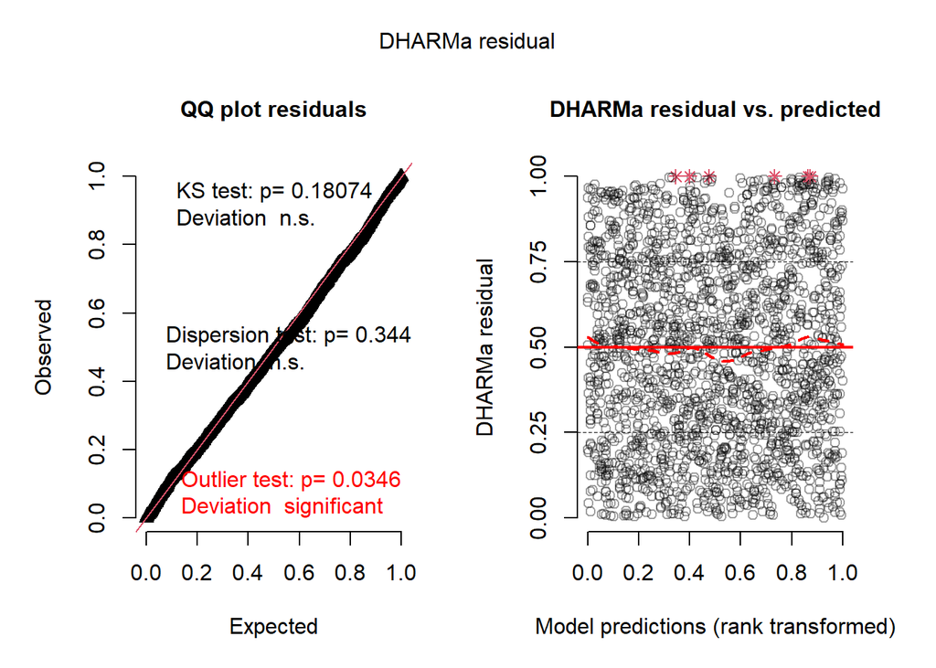

```r
sight_sdm_resid <- simulateResiduals(sight_sdm)
plot(sight_sdm_resid)
```

For the sightings data, we see a marginally non-significant difference between zones (0.0792) suggesting that the relationship between WhaleWatch and sightings may differ between zones. We do see that WhaleWatch has a positive significant relationship with sightings data in Socal (our reference level) and when HSI = 1, we expect a 2.6x increase in whales compared to when HSI = 0.

```r
exp(fixef(sight_sdm)$cond)
```

```
    (Intercept)            bwmv      zoneSF VSR       month_sin       month_cos
      0.4283132       2.6313615       1.3994725       0.5361666       0.2817825
bwmv:zoneSF VSR
      0.3410211
```

```r
emtrends(sight_sdm, pairwise ~ zone, var = "bwmv")
```

```
$emtrends
 zone      bwmv.trend    SE  df asymp.LCL asymp.UCL
 Socal VSR      0.968 0.451 Inf    0.0827      1.85
 SF VSR        -0.108 0.620 Inf   -1.3232      1.11

Confidence level used: 0.95

$contrasts
 contrast           estimate    SE  df z.ratio p.value
 Socal VSR - SF VSR     1.08 0.613 Inf   1.756  0.0792
```

## Acoustics ~ SDM

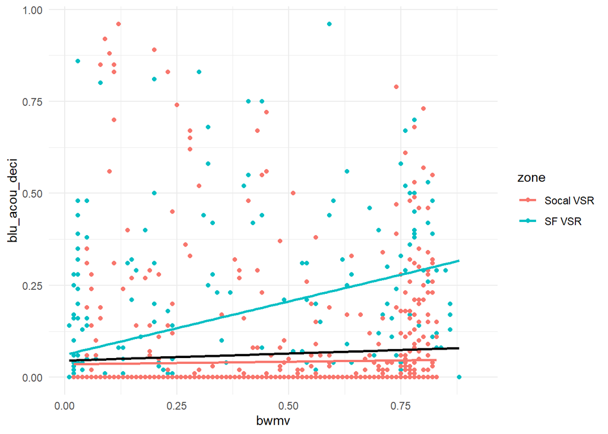

```r
ggplot(wpr, aes(bwmv, blu_acou_deci)) +
geom_point(aes(color = zone)) +
geom_smooth(data = wpr, aes(bwmv, blu_acou_deci), color = "black", method = "lm", se = FALSE) +
geom_smooth(method = "lm", aes(color = zone), se = FALSE) +
theme_minimal()
```

```r
n_acou_mod <- wpr %>% filter(!is.na(blu_acou_deci)) %>% filter(!is.na(bwmv)) %>% group_by(zone)
count(n_acou_mod, "zone")
```

```
# A tibble: 2 × 3
# Groups:   zone [2]
  zone      `"zone"`     n
  <fct>     <chr>    <int>
1 Socal VSR zone      1089
2 SF VSR    zone       290
```

```r
#acoustics ~ sdm
acou_sdm <- glmmTMB(blu_acou_deci ~ bwmv*zone + month_sin + month_cos + (1|year_c),
                    ziformula = ~zone,
                    family = beta_family(link = "logit"),
                    data = wpr)

summary(acou_sdm)
```

```
 Family: beta  ( logit )
Formula:
blu_acou_deci ~ bwmv * zone + month_sin + month_cos + (1 | year_c)
Zero inflation:                 ~zone
Data: wpr

      AIC       BIC    logLik -2*log(L)  df.resid
   1027.0    1079.3    -503.5    1007.0      1369

Random effects:

Conditional model:
 Groups Name        Variance Std.Dev.
 year_c (Intercept) 0.03366  0.1835
Number of obs: 1379, groups:  year_c, 5

Dispersion parameter for beta family (): 4.48

Conditional model:
                Estimate Std. Error z value Pr(>|z|)
(Intercept)      -0.2267     0.2351  -0.964   0.3349
bwmv             -2.8751     0.4981  -5.772 7.84e-09 ***
zoneSF VSR       -0.7654     0.2465  -3.105   0.0019 **
month_sin        -1.2903     0.2347  -5.498 3.84e-08 ***
month_cos         0.0219     0.1150   0.191   0.8489
bwmv:zoneSF VSR   1.8131     0.3588   5.053 4.34e-07 ***
---
Signif. codes:  0 '***' 0.001 '**' 0.01 '*' 0.05 '.' 0.1 ' ' 1

Zero-inflation model:
            Estimate Std. Error z value Pr(>|z|)
(Intercept)  1.43168    0.07681   18.64   <2e-16 ***
zoneSF VSR  -1.61147    0.14073  -11.45   <2e-16 ***
---
Signif. codes:  0 '***' 0.001 '**' 0.01 '*' 0.05 '.' 0.1 ' ' 1
```

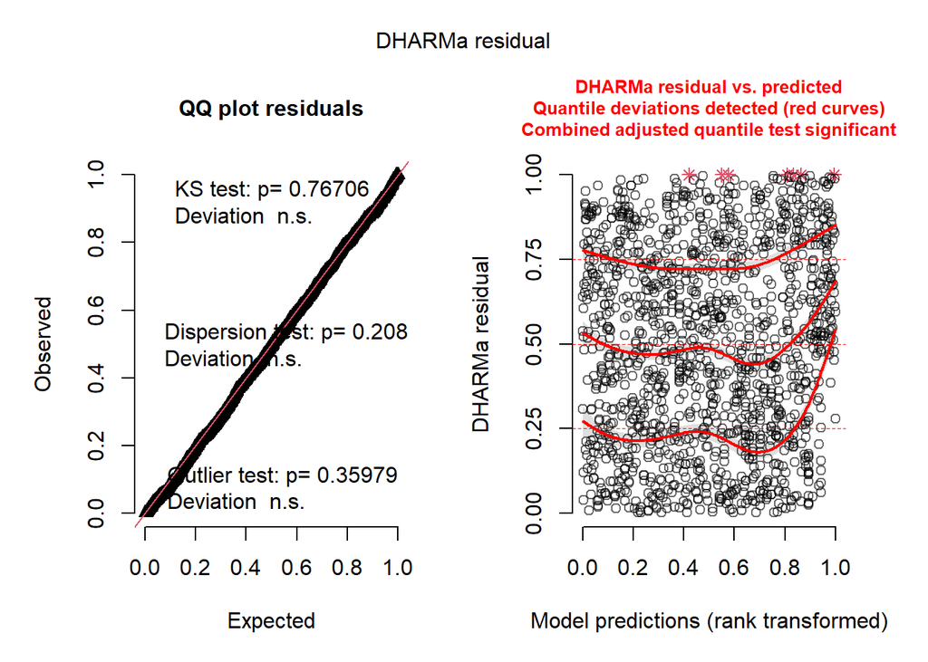

```r
acou_sdm_resid <- simulateResiduals(acou_sdm)
plot(acou_sdm_resid)
```

```r
plogis(fixef(acou_sdm)$cond)*100 #baseline for SF VSR at mean year, mean month, and bwmv = 0
```

```
    (Intercept)            bwmv      zoneSF VSR       month_sin       month_cos
       44.35579         5.33980        31.74652        21.58014        50.54757
bwmv:zoneSF VSR
       85.97387
```

```r
emtrends(acou_sdm, pairwise ~ zone, var = "bwmv")
```

```
$emtrends
 zone      bwmv.trend    SE  df asymp.LCL asymp.UCL
 Socal VSR      -2.88 0.498 Inf     -3.85    -1.899
 SF VSR         -1.06 0.400 Inf     -1.85    -0.279

Confidence level used: 0.95

$contrasts
 contrast           estimate    SE  df z.ratio p.value
 Socal VSR - SF VSR    -1.81 0.359 Inf  -5.053 <0.0001
```